# Lab2

Group 2: Jin Chang, Carmelita Deleon, Kevin Kho, Billy, Alisha

1/25/2019

# Part 1

## First

- Beijing, located in [northern China](https://en.wikipedia.org/wiki/North_China), is governed as a [municipality](https://en.wikipedia.org/wiki/Direct-administered_municipalities_of_China) under the direct administration of [central government](https://en.wikipedia.org/wiki/Government_of_the_People%27s_Republic_of_China) with [16 urban, suburban, and rural districts](https://en.wikipedia.org/wiki/List_of_administrative_divisions_of_Beijing).
- Shanghai (Chinese: 上海, Mandarin pronunciation: [ʂâŋ.xài] (About this soundlisten), Wu pronunciation: [zɑ̃.hɛ] (About this soundlisten)) is one of the four municipalities under the direct administration of the central government of the People’s Republic of China, the largest city in China by population,
- Municipality A municipality (simplified Chinese: 直辖市; traditional Chinese: 直轄市; pinyin: zhíxiáshì; literally: “direct-administrated city”) or municipality directly under the administration of the central government is a higher level of city which is directly under the Chinese government, with status/rank equal to that of the provinces. In practice, their political status is higher than that of common provinces.
- A municipality is a “city” ([Chinese](https://en.wikipedia.org/wiki/Chinese_language): 市; [pinyin](https://en.wikipedia.org/wiki/Pinyin): shì) with “provincial” (Chinese: 省级; pinyin: shěngjí) power under a unified jurisdiction. As such it is simultaneously a city and a province of its own right.
- A municipality is often not a “[city](https://en.wikipedia.org/wiki/City)” in the usual sense of the term (i.e., a large continuous urban settlement), but instead an administrative unit comprising, typically, a main central urban area (a city in the usual sense, usually with the same name as the municipality), and its much larger surrounding [rural](https://en.wikipedia.org/wiki/Rural) area containing many smaller cities (districts and subdistricts), towns and villages. The larger municipality spans over 100 kilometres (62 mi). To distinguish a “municipality” from its actual urban area (the traditional meaning of the word city), the term “urban area” (Chinese: 市区) is used.
- The People’s Republic of China (PRC) claims the island of Taiwan and its surrounding islets, including Penghu, as “Taiwan Province”, though Taiwan has not been under control of a government that ruled from mainland China since 1949, when the Republic of China lost the mainland to the Communist Party of China, which established the PRC. The territory is controlled by the Republic of China (ROC, commonly called “Taiwan”). -The whole of Tibet is illegally occupied by PRC.

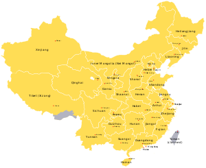

# Part 2

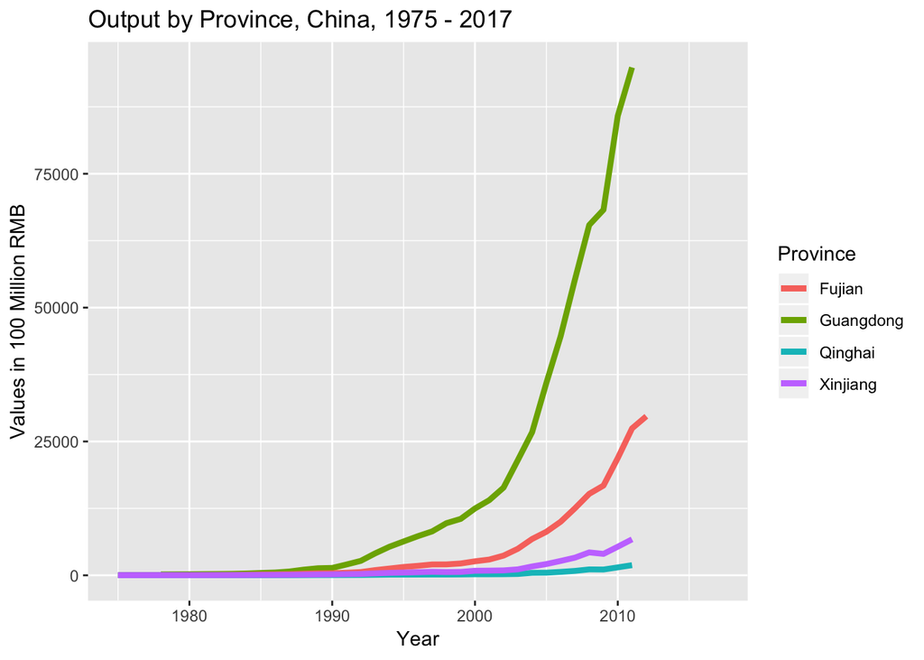

Here we have a chart showing the output, in 100 million RMB, for 4 Provinces in China from 1975 through 2017. Output has been relatively flat for these 4 provinces up until 1990. At around that point, there appears to be a divergence in output increase, with some provinces experiencing greater output growth than others. What might explain this? Qinghai and Xinjiang are on the western part of the country, where the terrain is mountainous and fragmented, isolating those areas from the rest of the country. On the other hand, Guangdong and Fujian are along the coast where industrialization and economic activity are greater [(Batisse 2005)](https://journals.openedition.org/chinaperspectives/502).

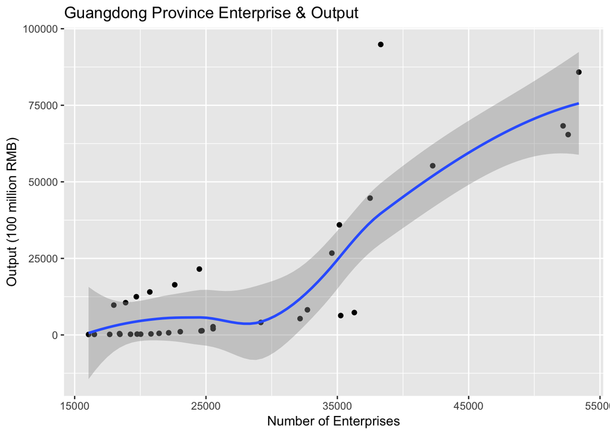

Focusing in on Guangdong Province from the previous chart, this chart displays the relationship between the number of enterprises and output. Generally, the greater the number of enterprises the greater the output. Howerver, that isn’t always the case as there are some instances of lower numbers of enterprises yet high output. When there are low numbers of enterprises but output remains high, that may be an indicator for greater instances of mergers/acquisitions and/or increased productivity.

# Part 3

## First

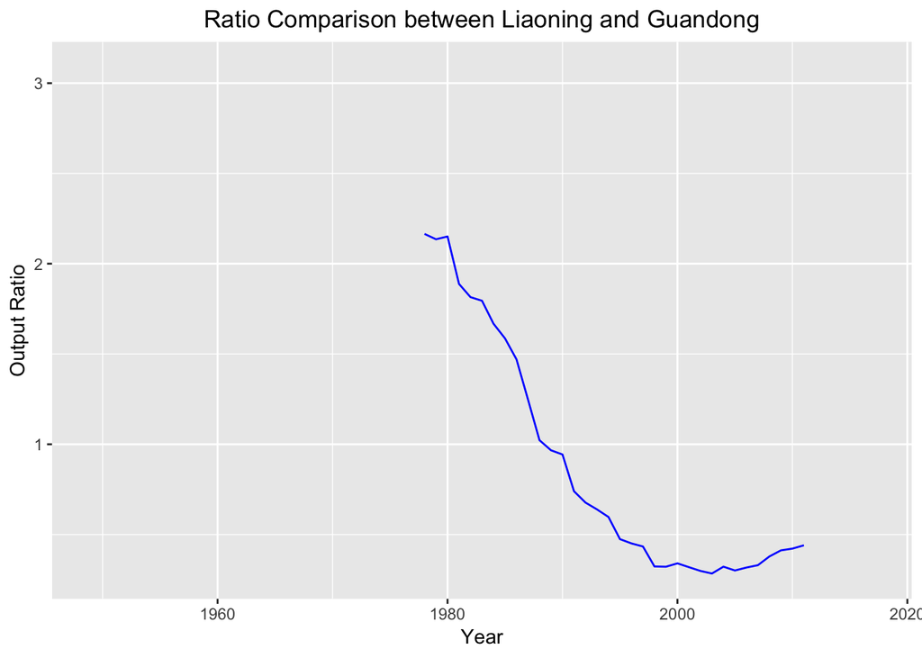

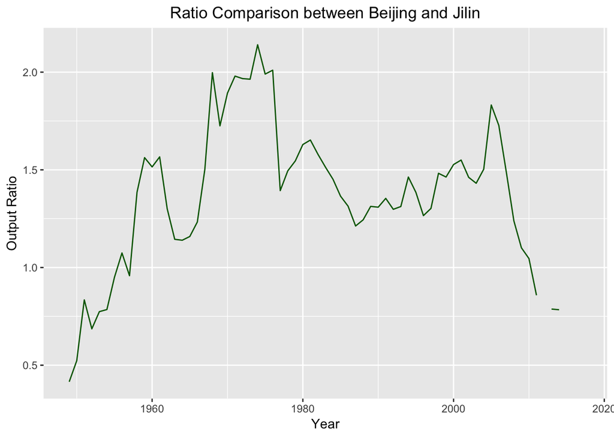

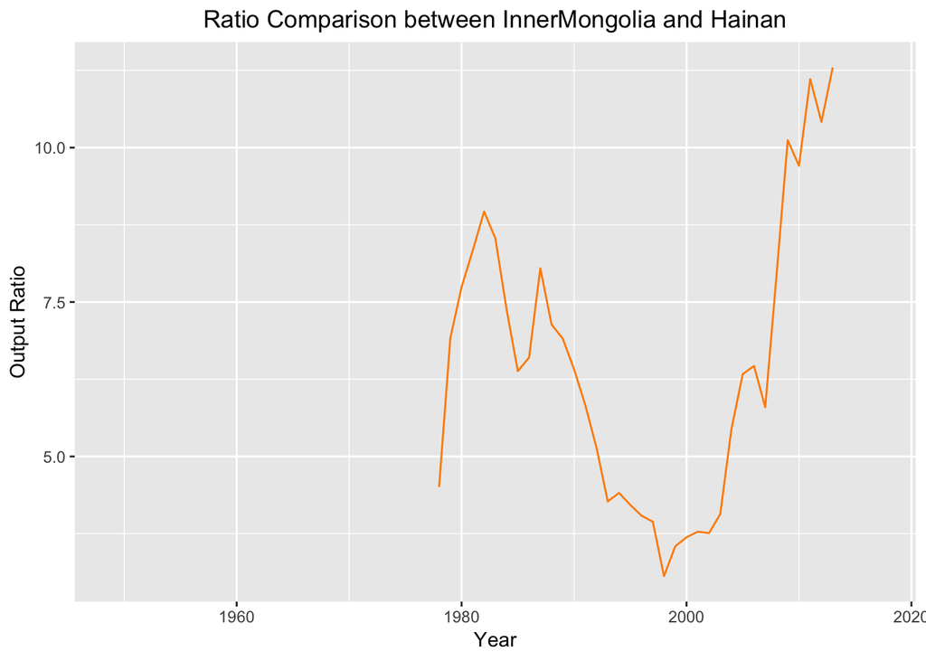

### How we treated NA Values

We did not modify or remove the NA values during the calculation or while plotting because we believe that there may be a loss in data. Furthermore, we believe the ommission of this values may impact the analysis negatively.

## Second

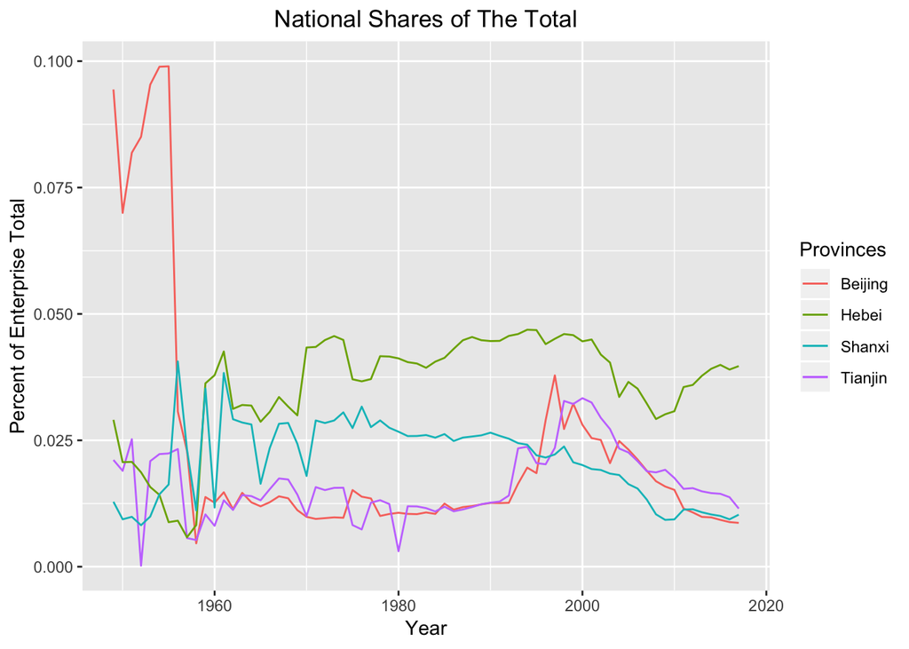

## Third

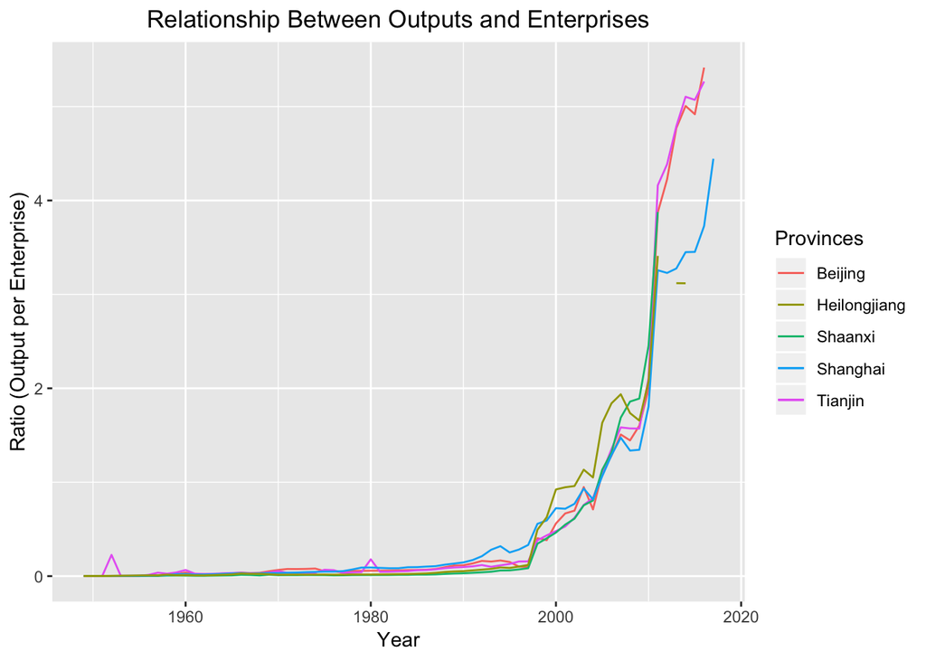